# Notebook

```python
import numpy as np
import matplotlib.pyplot as plt
%run PcapParser.py
%matplotlib inline
```

### Log of parsing pcap

```python
xmlLs = os.listdir("./xml")
xmlLs = [item for item in xmlLs if item.endswith('xml')]
senarioMap = {}
webMap = {}
sidMap = []
widMap = []
summaryLog = open("log.txt", 'w')
psrLs = []
for idx, xml in enumerate(xmlLs):
    print idx, xml
    ls = xml.split("_")
    senario = ls[0]+"_"+ls[1]
    web = ls[2]
    eventLogName = "./log/"+ xml.replace(".xml", ".log")
    eventLog = open(eventLogName, 'w')
    xmlFile = "./xml/" + xml
    psr = PcapParser(xmlFile, senario, web, summaryLog, eventLog)
    psr.analyze()
    psr.log()
    if senario not in senarioMap:
        senarioMap[senario] = len(sidMap)
        sidMap.append(senario)
    sid = senarioMap[senario]
    if web not in webMap:
        webMap[web] = len(webMap)
        widMap.append(web)
    wid = webMap[web]
    psrLs.append((wid, sid, psr))
```

```
0 t-mobile_android_adobe.com_1329414692.24.xml
-------- Summary --------
senario: t-mobile_android web: adobe.com
start_time: 0.0 end_time: 24.220435
pktLoss: 113 pktCnt: 1094
tcpTime: 10.493535 objTime: 17.383141 dnsTime 3.128412
avgObjTime: 0.327983792453 varObjTime: 0.226308529241
eventCnt: 117
tcpCnt: 59 objCnt: 53 dnsCnt: 5
failEventCnt: 3
tcpFailCnt: 0 objFailCnt: 3 dnsFailCnt: 0
rttSum: 23.524275
diffSiteCnt: 6
1 t-mobile_android_amazon.com_1329408864.54.xml
-------- Summary --------
senario: t-mobile_android web: amazon.com
start_time: 0.0 end_time: 12.456418
pktLoss: 18 pktCnt: 139
tcpTime: 1.216278 objTime: 2.878627 dnsTime 5.382996
avgObjTime: 0.411232428571 varObjTime: 0.0185680721048
eventCnt: 20
tcpCnt: 9 objCnt: 7 dnsCnt: 4
failEventCnt: 2
tcpFailCnt: 0 objFailCnt: 2 dnsFailCnt: 0
rttSum: 4.115517
diffSiteCnt: 2
2 t-mobile_android_aol.com_1329414398.57.xml
-------- Summary --------
senario: t-mobile_android web: aol.com
start_time: 0.0 end_time: 15.933138
pktLoss: 32 pktCnt: 1551
tcpTime: 17.622198 objTime: 36.64983 dnsTime 5.278188
avgObjTime: 0.469869615385 varObjTime: 0.285545191325
eventCnt: 169
tcpCnt: 84 objCnt: 78 dnsCnt: 7
failEventCnt: 3
tcpFailCnt: 0 objFailCnt: 3 dnsFailCnt: 0
rttSum: 41.678679
diffSiteCnt: 6
3 t-mobile_android_cnn.com_1329413778.7.xml
```

[output cut: 517 more lines]

```
rttSum: 137.668992
diffSiteCnt: 20
43 wired_firefox_twitter.com_1329407814.16.xml
-------- Summary --------
senario: wired_firefox web: twitter.com
start_time: 0.0 end_time: 8.120155
pktLoss: 323 pktCnt: 718
tcpTime: 0.436586 objTime: 0.731467 dnsTime 0.024839
avgObjTime: 0.0609555833333 varObjTime: 0.00296471746091
eventCnt: 43
tcpCnt: 10 objCnt: 12 dnsCnt: 21
failEventCnt: 1
tcpFailCnt: 0 objFailCnt: 1 dnsFailCnt: 0
rttSum: 0.906961
diffSiteCnt: 5
```

### Web performance across these scenarios

```python
import numpy as np
wlen = len(widMap)
slen = len(senarioMap)
timePerf = np.zeros((wlen, slen))
lossPerf = np.zeros((wlen, slen))
rttPerf = np.zeros((wlen, slen))
objTimePerf = np.zeros((wlen, slen))
dnsTimePerf = np.zeros((wlen, slen))
tcpTimePerf = np.zeros((wlen, slen))
objCnt = np.zeros((wlen, slen))
dnsCnt = np.zeros((wlen, slen))
tcpCnt = np.zeros((wlen, slen))
avgObjTime = np.zeros((wlen, slen))
varObjTime = np.zeros((wlen, slen))
eventCnt = np.zeros((wlen, slen))
failEventCnt = np.zeros((wlen, slen))
diffSiteCnt = np.zeros((wlen, slen))
dnsFailCnt = np.zeros((wlen, slen))
for wid, sid, psr in psrLs:
    timePerf[wid][sid] = psr.end_time - psr.start_time
    lossPerf[wid][sid] = psr.pktLoss*1.0/psr.pktCnt
    rttPerf[wid][sid]  = psr.rttSum
    dnsTimePerf[wid][sid] = psr.dnsTime
    tcpTimePerf[wid][sid] = psr.tcpTime
    objTimePerf[wid][sid] = psr.objTime
    dnsCnt[wid][sid] = psr.dnsCnt
    tcpCnt[wid][sid] = psr.tcpCnt
    objCnt[wid][sid] = psr.objCnt
    avgObjTime[wid][sid] = psr.avgObjTime
    varObjTime[wid][sid] = psr.varObjTime
    failEventCnt[wid][sid] = psr.failEventCnt
    eventCnt[wid][sid] = psr.eventCnt
    diffSiteCnt[wid][sid] = psr.diffSiteCnt
    dnsFailCnt[wid][sid] = psr.dnsFailCnt
```

```python
def showPerf(perf, chk = True):
    print '%15s'% " ",
    for sid, senario in enumerate(sidMap):
        print '%15s'% senario,
    print
    for wid, web in enumerate(widMap):
        print '%15s' % web,
        for sid, senario in enumerate(sidMap):
            if chk and perf[wid][sid] == 0:
                print '%15s' % '###',
            else:
                print '%15f' % perf[wid][sid],
        print
```

### Time Performance

```python
showPerf(timePerf)
```

```
                t-mobile_android t-mobile_firefox verizon_firefox   wired_android   wired_firefox
      adobe.com       24.220435        7.806630             ###       26.199881       10.045967
     amazon.com       12.456418        7.202773        8.024479       13.146432        8.549684
        aol.com       15.933138       28.521616             ###             ###        9.535227
        cnn.com       22.502203        9.257303       33.422131       14.920534        9.396641
     google.com       18.226168       16.641248       12.531072       11.815483        7.951650
  microsoft.com       13.346751        8.831774       16.384754       21.147349       10.303914
         qq.com       27.379611       12.408945             ###       26.778238       13.160087
  rakuten.co.jp       23.729219       14.993559             ###       23.769265       11.786224
     taobao.com       29.904979       10.712950             ###       43.446405       20.723620
    twitter.com        3.931296       30.694358       18.009581       10.956266        8.120155
```

### Packet Loss Rate

```python
showPerf(lossPerf)
```

```
                t-mobile_android t-mobile_firefox verizon_firefox   wired_android   wired_firefox
      adobe.com        0.103291        0.168472             ###        0.199422        0.145474
     amazon.com        0.129496        0.133721        0.107143        0.136752        0.124372
        aol.com        0.020632        0.122468             ###             ###        0.134121
        cnn.com        0.143251        0.182745        0.160417        0.164114        0.136757
     google.com        0.164882        0.261538        0.181818        1.000000        0.156812
  microsoft.com        0.092332        0.116864        0.106734        0.087037        0.103896
         qq.com        0.023383        0.134126             ###        0.043347        0.103448
  rakuten.co.jp        0.032926        0.171412             ###        0.048133        0.199360
     taobao.com        0.060937        0.140921             ###        0.249561        0.197789
    twitter.com             ###        0.125280        0.124384             ###        0.449861
```

### Sum of RTT time

```python
showPerf(rttPerf)
```

```
                t-mobile_android t-mobile_firefox verizon_firefox   wired_android   wired_firefox
      adobe.com       23.524275       21.890127             ###        7.911924        5.554526
     amazon.com        4.115517       20.421755       24.882552        0.343676        0.464328
        aol.com       41.678679       64.999299             ###             ###        7.782804
        cnn.com       10.425217       42.270242      216.814465        1.548719        2.621477
     google.com        2.934715        9.304611       13.266260             ###        0.516028
  microsoft.com       20.543745       18.958546       68.289920       13.224909        4.659342
         qq.com       41.482744       29.882565             ###       49.374347       42.042697
  rakuten.co.jp       37.268900       66.622315             ###        5.731762       14.125286
     taobao.com       18.983544       56.939613             ###       79.686025      137.668992
    twitter.com        0.447250        9.915678       19.379234        0.234695        0.906961
```

### Which stages in the Web downloads take the maximum time for what scenario?

```python
def showStagePerf():
    print '%15s'% " ",
    for sid, senario in enumerate(sidMap):
        print '%15s'% senario,
    print
    for wid, web in enumerate(widMap):
        print '%15s' % web,
        for sid, senario in enumerate(sidMap):
            if dnsTimePerf[wid][sid] == 0:
                 print '%15s' % '###',
            elif dnsTimePerf[wid][sid] > tcpTimePerf[wid][sid]:
                if dnsTimePerf[wid][sid] > objTimePerf[wid][sid]:
                    print '%15s' % ('dns '+str(dnsTimePerf[wid][sid])),
                else:
                    print '%15s' % ('obj '+str(objTimePerf[wid][sid])),
            else:
                if tcpTimePerf[wid][sid] > objTimePerf[wid][sid]:
                    print '%15s' % ('tcp '+str(tcpTimePerf[wid][sid])),
                else:
                    print '%15s' % ('obj '+str(objTimePerf[wid][sid])),
        print
showStagePerf()
```

```
                t-mobile_android t-mobile_firefox verizon_firefox   wired_android   wired_firefox
      adobe.com   obj 17.383141   obj 18.376675             ###    obj 5.722402    obj 5.502509
     amazon.com    dns 5.382996   obj 15.299642   obj 36.640516    dns 3.767106    dns 1.751264
        aol.com    obj 36.64983   obj 42.616462             ###             ###    obj 8.923312
        cnn.com    dns 9.722581     obj 35.6082  obj 228.789167    obj 0.788943    obj 5.168214
     google.com    obj 6.190624   obj 10.466345   obj 16.622363             ###    obj 0.605371
  microsoft.com   obj 17.042458   obj 17.189217   obj 62.829613   obj 12.392258    obj 4.503431
         qq.com   obj 84.997519   obj 32.634912             ###    obj 31.57688   obj 38.522019
  rakuten.co.jp   obj 28.411562   obj 68.214611             ###   obj 28.998971   obj 15.997801
     taobao.com     obj 19.2532   obj 72.746766             ###   tcp 45.922049  obj 116.009527
    twitter.com    dns 2.927267   obj 33.091008    obj 21.72856    tcp 0.160657    obj 0.731467
```

#### verizon_firefox with cnn.com under object download stage has the maximum download time

### Time taken for DNS requests and their variations

```python
showPerf(dnsTimePerf)
```

```
                t-mobile_android t-mobile_firefox verizon_firefox   wired_android   wired_firefox
      adobe.com        3.128412        0.552554             ###        0.685461        1.680071
     amazon.com        5.382996        0.197834        6.399755        3.767106        1.751264
        aol.com        5.278188        2.270175             ###             ###        0.113270
        cnn.com        9.722581        2.749436       58.638470        0.318052        1.788192
     google.com        4.490366        1.331357        1.434356             ###        0.008105
  microsoft.com        2.822611        0.902109       28.507232        1.364997        0.995562
         qq.com       12.439214        4.115289             ###       10.370199        1.498538
  rakuten.co.jp        7.645832        3.410223             ###        5.012726        0.679220
     taobao.com        8.612200        2.877280             ###        5.385410        3.307248
    twitter.com        2.927267        0.674654       10.056749        0.004881        0.024839
```

### Loss characteristics of DNS requests; can you detect any DNS request timeouts and repeat requests in the same download

#### Yes, the followint table is the DNS timeout count we detected in different scenarios and webs

```python
showPerf(dnsFailCnt, False)
```

```
                t-mobile_android t-mobile_firefox verizon_firefox   wired_android   wired_firefox
      adobe.com        0.000000        0.000000        0.000000        1.000000        0.000000
     amazon.com        0.000000        0.000000        0.000000        0.000000        0.000000
        aol.com        0.000000        0.000000        0.000000        0.000000        0.000000
        cnn.com        0.000000        0.000000        8.000000        0.000000        0.000000
     google.com        0.000000        1.000000        3.000000        4.000000        0.000000
  microsoft.com        0.000000        0.000000        0.000000        0.000000        0.000000
         qq.com        0.000000        0.000000        0.000000        1.000000        0.000000
  rakuten.co.jp        1.000000        0.000000        0.000000        0.000000        0.000000
     taobao.com        1.000000        0.000000        0.000000        0.000000        0.000000
    twitter.com        0.000000        0.000000        0.000000        0.000000        0.000000
```

### Number of objects per web page download

#### The following table is the object count for different scenarios and webs

```python
showPerf(objCnt)
```

```
                t-mobile_android t-mobile_firefox verizon_firefox   wired_android   wired_firefox
      adobe.com       53.000000       58.000000             ###       54.000000       60.000000
     amazon.com        7.000000       49.000000       33.000000        7.000000       77.000000
        aol.com       78.000000       65.000000             ###             ###       66.000000
        cnn.com       23.000000      106.000000      108.000000       23.000000      116.000000
     google.com        6.000000       12.000000       10.000000             ###       13.000000
  microsoft.com       39.000000       52.000000       50.000000       39.000000       52.000000
         qq.com       96.000000      100.000000             ###       77.000000      100.000000
  rakuten.co.jp       81.000000      287.000000             ###       82.000000      282.000000
     taobao.com       54.000000      166.000000             ###       49.000000      149.000000
    twitter.com        1.000000       13.000000       13.000000        1.000000       12.000000
```

### Number of different sites used for each download

```python
showPerf(diffSiteCnt)
```

```
                t-mobile_android t-mobile_firefox verizon_firefox   wired_android   wired_firefox
      adobe.com        6.000000        6.000000             ###        6.000000        6.000000
     amazon.com        2.000000        7.000000        7.000000        2.000000        9.000000
        aol.com        6.000000       11.000000             ###             ###       12.000000
        cnn.com        3.000000       19.000000       24.000000        3.000000       19.000000
     google.com        2.000000        2.000000        1.000000             ###        2.000000
  microsoft.com        4.000000        9.000000       10.000000        4.000000       10.000000
         qq.com       19.000000       18.000000             ###       14.000000       20.000000
  rakuten.co.jp       10.000000       18.000000             ###       11.000000       17.000000
     taobao.com        6.000000       16.000000             ###        4.000000       20.000000
    twitter.com        1.000000        7.000000        6.000000        1.000000        5.000000
```

### Number of TCP connections to different websites

```python
showPerf(tcpCnt)
```

```
                t-mobile_android t-mobile_firefox verizon_firefox   wired_android   wired_firefox
      adobe.com       59.000000       21.000000             ###       63.000000       21.000000
     amazon.com        9.000000       23.000000       21.000000        9.000000       26.000000
        aol.com       84.000000       42.000000             ###             ###       38.000000
        cnn.com       29.000000       48.000000       79.000000       29.000000       46.000000
     google.com        8.000000        8.000000        7.000000             ###        8.000000
  microsoft.com       45.000000       21.000000       35.000000       46.000000       23.000000
         qq.com       98.000000       46.000000             ###       82.000000       56.000000
  rakuten.co.jp       86.000000       47.000000             ###       89.000000       48.000000
     taobao.com       56.000000       57.000000             ###       62.000000       91.000000
    twitter.com        2.000000       15.000000       16.000000        2.000000       10.000000
```

### Average download rate across objects for a given website

```python
showPerf(avgObjTime)
```

```
                t-mobile_android t-mobile_firefox verizon_firefox   wired_android   wired_firefox
      adobe.com        0.327984        0.316839             ###        0.105970        0.091708
     amazon.com        0.411232        0.312238        1.110319        0.095082        0.013772
        aol.com        0.469870        0.655638             ###             ###        0.135202
        cnn.com        0.267364        0.335926        2.118418        0.034302        0.044554
     google.com        1.031771        0.872195        1.662236             nan        0.046567
  microsoft.com        0.436986        0.330562        1.256592        0.317750        0.086604
         qq.com        0.885391        0.326349             ###        0.410089        0.385220
  rakuten.co.jp        0.350760        0.237682             ###        0.353646        0.056730
     taobao.com        0.356541        0.438234             ###        0.709285        0.778587
    twitter.com        0.205640        2.545462        1.671428        0.087407        0.060956
```

### Variation in the download rate across objects for a given website

```python
showPerf(varObjTime)
```

```
                t-mobile_android t-mobile_firefox verizon_firefox   wired_android   wired_firefox
      adobe.com        0.226309        0.033667             ###        0.006581        0.004442
     amazon.com        0.018568        0.084497        0.939781        0.015496        0.003370
        aol.com        0.285545        7.468700             ###             ###        0.014695
        cnn.com        0.013499        0.131690        4.790352        0.002044        0.024927
     google.com        1.250747        1.416202        3.342711             nan        0.000655
  microsoft.com        0.149295        0.305886        0.938598        0.260638        0.019774
         qq.com        0.157264        0.261697             ###        0.047961        0.048321
  rakuten.co.jp        0.062461        0.102566             ###        0.086979        0.020711
     taobao.com        0.454202        0.238575             ###        0.907612        1.289691
    twitter.com             ###       34.929824        1.287593             ###        0.002965
```

### Do you observe timeouts? How frequent are they?

#### Yes, the following table is the timeout count we observed

```python
print "Timeout Count"
showPerf(failEventCnt)
```

```
Timeout Count
                t-mobile_android t-mobile_firefox verizon_firefox   wired_android   wired_firefox
      adobe.com        3.000000        2.000000             ###        5.000000        2.000000
     amazon.com        2.000000        4.000000       14.000000        2.000000        1.000000
        aol.com        3.000000        4.000000             ###             ###        3.000000
        cnn.com        6.000000        7.000000       54.000000        6.000000       13.000000
     google.com        2.000000        3.000000        7.000000        4.000000        2.000000
  microsoft.com        5.000000        2.000000        6.000000        5.000000        5.000000
         qq.com        1.000000        1.000000             ###        4.000000        1.000000
  rakuten.co.jp        3.000000        1.000000             ###        2.000000        2.000000
     taobao.com        3.000000        4.000000             ###       12.000000       21.000000
    twitter.com             ###             ###             ###             ###        1.000000
```

#### Timeout Frequency

```python
print "Timeout Frequency"
showPerf(failEventCnt/(failEventCnt + eventCnt))
```

```
Timeout Frequency
                t-mobile_android t-mobile_firefox verizon_firefox   wired_android   wired_firefox
      adobe.com        0.025000        0.019802             nan        0.038168        0.019802
     amazon.com        0.090909        0.042553        0.162791        0.086957        0.008000
        aol.com        0.017442        0.027397             nan             nan        0.017647
        cnn.com        0.095238        0.034483        0.168750        0.093750        0.047794
     google.com        0.105263        0.066667        0.233333        1.000000        0.036364
  microsoft.com        0.053763        0.017391        0.044776        0.051546        0.041322
         qq.com        0.004785        0.005587             nan        0.022346        0.004785
  rakuten.co.jp        0.016854        0.002653             nan        0.010695        0.005376
     taobao.com        0.024793        0.014981             nan        0.090909        0.063636
    twitter.com             ###             ###             ###             ###        0.022727
```

### The following analysis are based on t-mobile_android_adobe.com"

```python
xml = "t-mobile_android_adobe.com_1329414692.24.xml"
ls = xml.split("_")
senario = ls[0]+"_"+ls[1]
web = ls[2]
summaryLog = open("log.txt", 'w')
eventLogName = "./log/"+ xml.replace(".xml", ".log")
eventLog = open(eventLogName, 'w')
xmlFile = "./xml/" + xml
psr = PcapParser(xmlFile, senario, web, summaryLog, eventLog)
psr.analyze()
psr.log()
```

```
-------- Summary --------
senario: t-mobile_android web: adobe.com
start_time: 0.0 end_time: 24.220435
pktLoss: 113 pktCnt: 1094
tcpTime: 10.493535 objTime: 17.383141 dnsTime 3.128412
avgObjTime: 0.327983792453 varObjTime: 0.226308529241
eventCnt: 117
tcpCnt: 59 objCnt: 53 dnsCnt: 5
failEventCnt: 3
tcpFailCnt: 0 objFailCnt: 3 dnsFailCnt: 0
rttSum: 23.524275
diffSiteCnt: 6
```

```python
NewObjEventLs = []
for event in psr.fullEventQueue:
    if event.type == "NewObj":
        NewObjEventLs.append(event)
```

### Do a sequence number plot evolution for a few interesting flows (sequence number vs time). What can you learn from the sequence number plots?

#### The following are two example sequence number-time plots. Those plots usually start very slow and then suddenly boost up after a period of time

```
Second New Object Event Sequence Plot
```

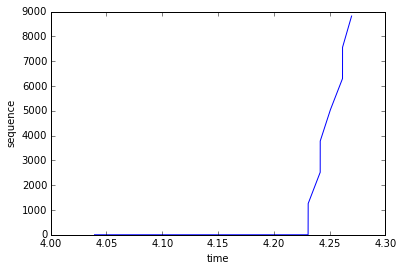

```python
i = 2
print "Second New Object Event Sequence Plot"
plt.plot(NewObjEventLs[i].seqFrame, NewObjEventLs[i].seqLs)
plt.ylabel('sequence')
plt.xlabel('time')
```

```
Third New Object Event Sequence Plot
```

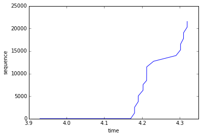

```python
i = 3
print "Third New Object Event Sequence Plot"
plt.plot(NewObjEventLs[i].seqFrame, NewObjEventLs[i].seqLs)
plt.ylabel('sequence')
plt.xlabel('time')
```

### Can you comment on the congestion window evolution across few of the sampled connections (DO NOT do this for many connections; its an elaborate process)?

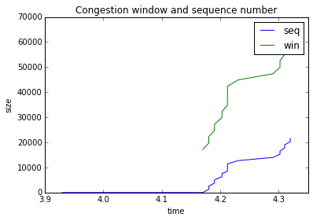

```python
i = 3
plt.plot(NewObjEventLs[i].seqFrame, NewObjEventLs[i].seqLs, label='seq')
plt.plot(NewObjEventLs[i].winFrame, NewObjEventLs[i].winLs, label='win')
plt.legend()
plt.ylabel('size')
plt.xlabel('time')
plt.title('Congestion window and sequence number')
```

### Does the congestion window match with the actual number of packets sent?

#### From above graph, sequence number is increase proportionally to conjection window size.